# Practical Machine Learning - Prediction Assignment

xbuRAw (GH)

December 27, 2019

## 0. Introduction

One thing that people regularly do is quantify how much of a particular activity they do, but they rarely quantify how well they do it. In this project, we will use data from accelerometers on the belt, forearm, arm, and dumbell of 6 participants and try to predict the manner in which they did the exercise. This is the “classe” variable in the training set.

This write up will consist of three sections:

1. Data loading and cleaning
2. Model testing, building and evaluation
3. Conclusion: Model selection, and final prediction.

## 1. Loading data and data pre-processing

```r
library(caret)
library(rpart)
library(randomForest)
library(nnet)
set.seed(111)
```

```r
trainUrl <- url("http://d396qusza40orc.cloudfront.net/predmachlearn/pml-training.csv")
testUrl <- url("http://d396qusza40orc.cloudfront.net/predmachlearn/pml-testing.csv")
rawTrainData <- read.csv(trainUrl, na.strings = c("NA","#DIV/0!",""))
rawTestData  <- read.csv(testUrl, na.strings = c("NA","#DIV/0!",""))
dim(rawTrainData)
```

```
## [1] 19622   160
```

The data set has 19622 observations of 160 variables. The first seven variables have no predictive value and can be discarded.

```r
# Excluding the first seven columns and all variables with NA entries
trainData <- rawTrainData[, -c(1:7)] # sample(c(1:19622), size = 100)
trainData <- trainData[,colSums(is.na(trainData)) == 0]
testData <- rawTestData[, -c(1:7)]
dim(trainData)
```

```
## [1] 19622    53
```

The tidied up data set has 53 remaining variables. We can now use the caret’s `createDataPartition` to split the data in training and test sets.

```r
partition <- createDataPartition(trainData$classe, p = .8, list = FALSE)
trainDF <- trainData[partition, ]
testDF <- trainData[-partition, ]
```

## 2. Model testing

All the models will be evaluated using caret’s `confusionMatrix` function. And make use of cross validation, via the `trainControl` `parameter method = repeatedcv`. We will only include the output for one model, otherwise the write up will be too long.

### 2.1 Model testing: Decision trees

```r
system.time(
  modelDT <- rpart(classe ~ ., method = "class", data = trainDF)
  )
predictDT <- predict(modelDT, testDF, type = "class")
cM <- confusionMatrix(predictDT, testDF$classe)
cM
```

The accuracy of the decision tree is 76.22%.

### 2.2 Model testing: Random Forest

The logical next step is to make the jump from a decision tree to a random forest model. We use the `randomForest` library instead of carets own implementation, because it performs better.

```r
system.time(
  modelRF <- randomForest(classe ~ ., data = trainDF, ntree = 100)
  )
```

```
##    user  system elapsed
##   9.547   0.172   9.817
```

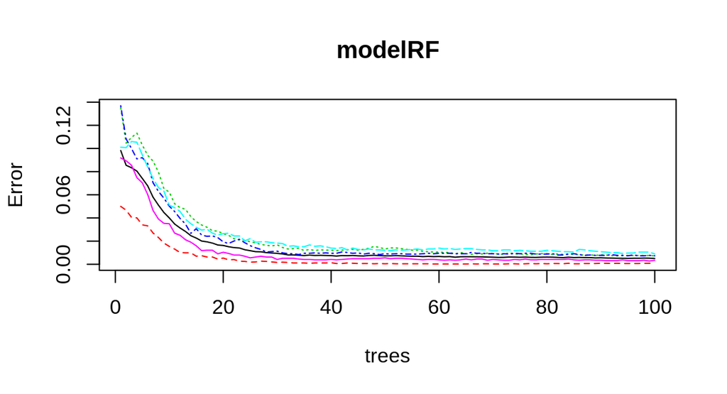

```r
plot(modelRF)
```

```r
predictRF <- predict(modelRF, testDF, type = "class")
cM <- confusionMatrix(predictRF, testDF$classe)
cM
```

```
## Confusion Matrix and Statistics
##
##           Reference
## Prediction    A    B    C    D    E
##          A 1116    5    0    0    0
##          B    0  754    5    0    0
##          C    0    0  678    5    0
##          D    0    0    1  638    3
##          E    0    0    0    0  718
##
## Overall Statistics
##
##                Accuracy : 0.9952
##                  95% CI : (0.9924, 0.9971)
##     No Information Rate : 0.2845
##     P-Value [Acc > NIR] : < 2.2e-16
##
##                   Kappa : 0.9939
##
##  Mcnemar's Test P-Value : NA
##
## Statistics by Class:
##
##                      Class: A Class: B Class: C Class: D Class: E
## Sensitivity            1.0000   0.9934   0.9912   0.9922   0.9958
## Specificity            0.9982   0.9984   0.9985   0.9988   1.0000
## Pos Pred Value         0.9955   0.9934   0.9927   0.9938   1.0000
## Neg Pred Value         1.0000   0.9984   0.9981   0.9985   0.9991
## Prevalence             0.2845   0.1935   0.1744   0.1639   0.1838
## Detection Rate         0.2845   0.1922   0.1728   0.1626   0.1830
## Detection Prevalence   0.2858   0.1935   0.1741   0.1637   0.1830
## Balanced Accuracy      0.9991   0.9959   0.9948   0.9955   0.9979
```

The accuracy of this model is 99.52%.

### 2.3 Model testing: GBM

Another popular machine learning algorithm is the gradien boosting machine (GBM).

```r
system.time(
  modelGBM <- train(classe ~ ., method = "gbm", data = trainDF,
    trControl = trainControl(method = "repeatedcv", number = 5, repeats = 1))
  )

predictGBM <- predict(modelGBM, testDF)
cM <- confusionMatrix(predictGBM, testDF$classe)
cM
```

This model has an accuracy of 95.92%.

### 2.4 Model testing: LDA

An LDA (Linear Discriminant Analysis) model can be seen as an close relative of logistic regression and is often used for classification problems with more than two classes.

```r
system.time(
  modelLDA <- train(classe ~ ., method = "lda", data = trainDF,
    trControl = trainControl(method = "repeatedcv", number = 5, repeats = 1))
  )
predictLDA <- predict(modelLDA, testDF)
cM <- confusionMatrix(predictLDA, testDF$classe)
cM
```

The accuracy of the LDA model is 70.43%.

### 2.5 Model testing: Deep learning with `nnet`

At last we will try a deep learning model using the `nnet` package.

```r
system.time(
  modelDL <- nnet(classe ~ ., trainDF, size = 5, rang = .1, decay = 5e-4, maxit = 100,
    trControl = trainControl(method = "repeatedcv", number = 5, repeats = 1))
  )
predictDL <- predict(modelDL, testDF, type = "class")
cM <- confusionMatrix(as.factor(predictDL), testDF$classe)
cM
```

The estimated accuracy of the DL model is 40.79%. The reason of this low score could be the one hidden layer limitation of the `nnet` library.

## 3. Conclusion

We trained five models and random forests performed best (accuracy score of 99.52%).

### 3.1 Score overview

Decision trees: 76.22%, Random Forest: 99.52%, GBM: 95.92%, LDA: 70.43%, DNN: 40.79%

### 3.3 Final prediction

```r
predict(modelRF, testData, type = "class")
```

```
##  1  2  3  4  5  6  7  8  9 10 11 12 13 14 15 16 17 18 19 20
##  B  A  B  A  A  E  D  B  A  A  B  C  B  A  E  E  A  B  B  B
## Levels: A B C D E
```